# Qualification et Sélection de logiciels Open Source (QSOS)

## Comment contribuer ?

L'objectif du projet QSOS est de mutualiser l'effort de veille sur les logiciels open source. Il se veut donc résolument communautaire : plus grand est le nombres de contributeurs plus grands sont le nombre, la qualité et l'objectivité des évaluations.

Vous pouvez contribuer au projet de plusieurs manières :

- en créant ou en mettant à jour des templates et des évaluations ;
- en traduisant les templates, les évaluation ou la documentation ;
- en participant au développement des outils du projet ;
- en faisant la promotion de la méthode et du projet.

Reportez-vous au site Web du projet QSOS pour plus de détails sur la gouvernance de la communauté QSOS.

# Annexe A : critères de Maturité QSOS

L'utilisation des critères ci-dessous, regroupés dans une section appelée « Maturité », est obligatoire pour tout template ou toute évaluation QSOS au format 2.0.

- Patrimoine : Historique et patrimoine du projet
  - Age du projet :
    - 0 : Inférieur à trois mois
    - 1 : Entre trois mois et trois ans
    - 2 : Supérieur à trois ans
  - Historique :
    - 0 : Le logiciel connaît de nombreux problèmes qui peuvent être rédhibitoires
    - 1 : Pas de problèmes majeurs, ni de crise ou historique inconnu
    - 2 : Bon historique de gestion de projet et de crise
  - Equipe de développement :
    - 0 : Très peu de développeurs identifiés ou développeur unique
    - 1 : Quelques développeurs actifs
    - 2 : Equipe de développement importante et identifiée
  - Popularité :
    - 0 : Très peu d'utilisateurs identifiés
    - 1 : Usage décelable
    - 2 : Nombreux utilisateurs et références
- Activité : Activité du et autour du projet
  - Communauté des contributeurs :
    - 0 : Pas de communauté ou de réelle activité (forum, liste de diffusion…)
    - 1 : Communauté existante avec une activité notable
    - 2 : Communauté forte : grosse activité sur les forums, de nombreux contributeurs et défenseurs
  - Activité autour des bugs :
    - 0 : Réactivité faible sur le forum ou sur la liste de diffusion, ou rien au sujet des corrections de bugs dans les notes de versions
    - 1 : Activité détectable mais sans processus clairement exposé, temps de résolution long
    - 2 : Forte réactivité, basée sur des rôles et des assignations de tâches
  - Activité autour des fonctionnalités :
    - 0 : Pas ou peu de nouvelles fonctionnalités
    - 1 : Évolution du produit conduite par une équipe dédiée ou par des utilisateurs, mais sans processus clairement exposé
    - 2 : Les requêtes pour les nouvelles fonctionnalités sont clairement outillées, feuille de route disponible
  - Activité sur les releases/versions :
    - 0 : Très faible activité que ce soit sur les versions de production ou de développement (alpha, beta)
    - 1 : Activité que ce soit sur les versions de production ou de développement (alpha, beta), avec des versions correctives mineures fréquentes
    - 2 : Activité importante avec des versions correctives fréquentes et des versions majeures planifiées liées aux prévisions de la feuille de route
- Gouvernance : Stratégie du projet
  - Détenteur des droits :
    - 0 : Les droits sont détenus par quelques individus ou entités commerciales
    - 1 : Les droits sont détenus par de nombreux individus de façon homogène
    - 2 : Les droits sont détenus par une entité légale, une fondation dans laquelle la communauté a confiance (ex: FSF, Apache, ObjectWeb)
  - Feuille de route :
    - 0 : Pas de feuille de route publiée
    - 1 : Feuille de route sans planning
    - 2 : Feuille de route versionnée, avec planning et mesures de retard
  - Pilotage du projet :
    - 0 : Pas de pilotage clair du projet
    - 1 : Pilotage dicté par un seul individu ou une entité commerciale
    - 2 : Indépendance forte de l'équipe de développement, droits détenus par une entité reconnue
  - Mode de distribution :
    - 0 : Existence d'une distribution commerciale ou propriétaire ou distribution libre limitée fonctionnellement
    - 1 : Sous-partie du logiciel disponible sous licence propriétaire (Coeur / Greffons...)
    - 2 : Distribution totalement ouverte et libre
- Industrialisation : Niveau d'industrialisation du projet
  - Services : Offres de services (Support, Formation, Audit...)
    - 0 : Pas d'offre de service identifiée
    - 1 : Offre existante mais restreinte géographiquement ou en une seule langue ou fournie par un seul fournisseur ou sans garantie
    - 2 : Offre riche, plusieurs fournisseurs, avec des garanties de résultats
  - Documentation :
    - 0 : Pas de documentation utilisateur
    - 1 : La documentation existe mais est en partie obsolète ou restreinte à une seule langue ou peu détaillée
    - 2 : Documentation à jour, traduite et éventuellement adaptée à différentes cibles de lecteurs (enduser, sysadmin, manager...)
  - Méthode qualité : Processus et méthode qualité
    - 0 : Pas de processus qualité identifié
    - 1 : Processus qualité existant, mais non formalisé ou non outillé
    - 2 : Processus qualité basé sur l'utilisation d'outils et de méthodologies standards
  - Modification du code :
    - 0 : Pas de moyen pratique de proposer des modifications de code
    - 1 : Des outils sont fournis pour accéder et modifier le code (ex : CVS, SVN) mais ne sont pas vraiment utilisés pour développer le produit
    - 2 : Le processus de modification de code est bien défini, exposé et respecté, basé sur des rôles bien définis

# Annexe B : framework Drakkr

QSOS est un sous-projet de l'initiative Drakkr visant à construire un framework libre dédié la gouvernance open source au sein des entreprises et administrations.

Outre QSOS, lié à l'adoption et à la veille sur les logiciels open source, Drakkr propose également d'autres méthodes et outils pour mettre en oeuvre une telle gouvernance.

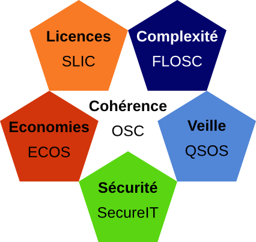

Framework Drakkr

- **OSC** (Open Source Cartouche) : sous-projet dédié à l'identification unique d'une version d'un logiciel open source ainsi qu'à la gestion des ses metadonnées ;
- **ECOS** (Evaluation des Coûts liés à l'adoption de logciels Open Source) : sous-projet relatif à l'évaluation et au calcul du coût total de prossession d'un logiciel open source ainsi qu'au retour sur investissement d'une migration ;
- **FLOSC** (Free/Libre Open Source Complexity) : sous-projet proposant une méthode et un outil d'évaluation de la complexité d'un logiciel open source ;
- **SLIC** (Software LIcense Comparator) : sous-projet dédié à la description formelle des licences open source et de leur compatibilités respectives ;
- **SecureIT** : sous-projet dédié à la gestion des alertes de sécurité dans les logiciels open source.

Consultez le site Web du projet Drakkr pour plus de détails : [`http://www.drakkr.org`](http://www.drakkr.org).

[^1]: [`http://slic.drakkr.org`](http://slic.drakkr.org)
[^2]: [`http://freemind.sourceforge.net`](http://freemind.sourceforge.net)
[^3]: [`http://daringfireball.net/projects/markdown/`](http://daringfireball.net/projects/markdown/)
[^4]: [`http://johnmacfarlane.net/pandoc/`](http://johnmacfarlane.net/pandoc/)
[^5]: [`http://gitit.net`](http://gitit.net)